# NLP Notes

# Getting started with NLP

https://medium.com/@gon.esbuyo/get-started-with-nlp-part-i-d67ca26cc828

## What is NLP?

Natural Language Processing (NLP) – appllication of computational techniques to the analysis and sunthesis of natural language and speech. Using algorithms to understand and manpipulate human language and speech.

Machine Learning (ML), Deep Learning (neural nets) are a set of tools used to solve NLP tasks.

## Challenges of NLP

**Ambiguity** - Understanding and modelling elements with *various contexts*. Words are unique but can have different meanings in different contexts. There exists a difference between the **signifier** (representation of information, *word*) and the **signified** (the meaning of that information, *concept*)

**Synonymy** - Expressing the same idea with different terms. Example *fine* is synonym of *thin* in the context of density, or synonym of *fee* in the case of punshiments.

**Syntax** - Several rules and irregularities with different cases of sentence construction.

**Coreference** - Reference to specific concepts that were mentioned earlier or directly omitted because they are deduced from context.

**Normalisation vs Information** - Generalising language. All lower case, convert plural words to singular ones if we don’t want to consider *dog* and *dogs* as two separate entities. When we normalise, we are losing part of the information in exchange to generalise it better.

**Representation** - Discrete values of letters (can’t estimate a value between ‘a’ and ‘b’). Solution is to transform words into vectors,( *word embeddings* ).

**Peronalisty, intention and style** - Irony, sarcasm.

## Basic NLP Techniques

### a) Stemming and lemmatising

Reducing forms of a word to a common base form.

> I **am** a student -> {am|are|is} -> I **be** a student

> My **dog’s** fur **is** dark -> {dog|dogs|dog’s|dogs’} -> dog} -> My **dog** fur **be** dark

Stemming chops of ends of words, the obtained element is known as the **stem**.

Lemmisatsion uses vocabulary and mophological analysis of words to return the case or dctionary form of a word, known as a **lemma**.

*Stemming* > I **saw** an amazing thing -> I **s** an amazing thing

*Lemmisation* > I **saw** an amazing thing -> I **see** an amazing thing

This removes variation/information in our corpus, but it’s necessary for generalisation.

### b) Coreference resolution

Solving coreferences in the corpus, part of normalising or preprocessing task.

### c) Part-of-speech (POS) Tagging

Marking words in a corpus by assigning a syntatic category.

- *Open class categories or types* (those with relatively fixed membership): **noun, verb, adjective, adverb**
- *Closed class types*: **preposition, determiner, pronoun, conjunction, auxiliary verb, particle, numeral.**

I (Preposition) want (verb) to play (verb) the piano (noun)

### d) Dependency Parsing

Instead of categorising (POS tag), we may want to know the role of that word in a specific sentence of our corpus. The objective is to obtain the dependencies or relations of words in the format of a dependency tree.

The considered dependencies are general terms: **subject, object, complement and modifier**

SpaCy’s dependency tree can be visualised with displaCy.

`want — I: nominal subject.`

`want — play: open clausal complement.`

`play — to: auxiliary verb.`

`play — the piano: direct object`

Where a—b:R means “_b is R of a“.” *The piano is direct object of play* " where *play—the piano: direct object*

### e) Name Entity Recognition (NER)

Creating a semantic field depndent of a context (entity). E.g. ‘Batman’ and ‘Avatar’ are instances of a group called ‘films’. But ‘Steven Spielberg’ is categorised as a ‘director’. NER is to detect relevant entities in our corpus.

“James Cameron (director) filmed part of Avatar (film) in New Zealand (location)”

# Overview of an NLP workflow

https://medium.com/@gon.esbuyo/get-started-with-nlp-part-ii-overview-of-an-nlp-workflow-7ba1f5948b24

## NPL workflow

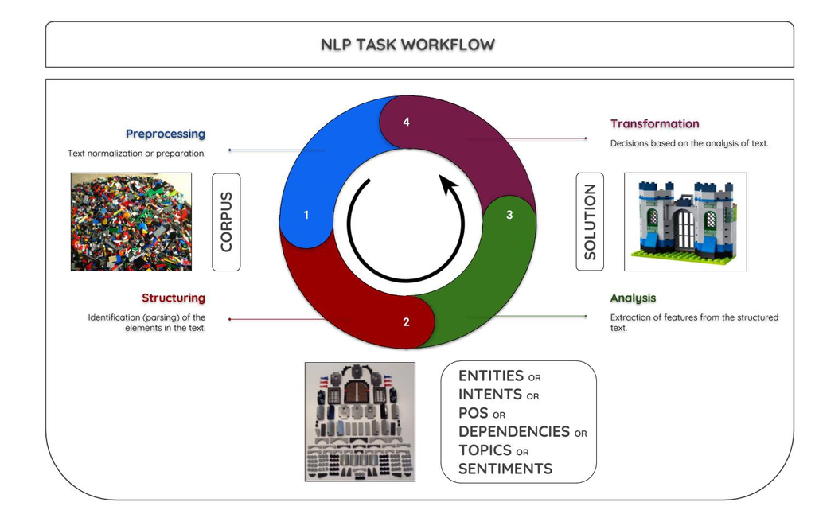

## 1. Preprocessing

There are two main types of data:

1. **Structured data**: Data tables, data.frames, SQL tables.
2. **Unstructured data**: Information we consume that has no well defined systematic structure. Natural language is *unstructured* data.

NLP provides a set of tools to structure natural language for different purposes. Our dataset is alled a corpus (corpora for plural).

Preproessing -> Text normalisation (or data preparation).

## 2. Structuring

Organising corpus in different ways.

- **Entities**
- **Intents**
- **POS tagging**
- **Dependency Parsing**
- **Topic Modelling**
- **Sentiment analysis**

## 3. Analysis

We can now proceed to look at structured information.

## Transformation

Using NLP to fulfill a purpose. Translating the obtained information into an interpretable source to make decisions, observe or analyse. Could be data visualiastion, proportins, predominant detected class, language generation, speech synthesis.